# Data Handling: Solutions

## Part I

### Exercise 1: Basics in R

```r
library(AER)
data(Guns)
```

#### 1.1

We can use the function `str()` to get this information.

```r
str(Guns)
```

#### 1.2

We cannot compute `sum(Guns$year)` because the variable year is a factor. The function `sum()` is not meaningful for factors.

#### 1.3

```r
Guns$year_num <- as.numeric(Guns$year)
str(Guns$year_num)
```

Factors are stored as a vector of integer values with a corresponding set of character values. When we convert the factor to numeric, the integer values are used. To use the character values, we first have to convert it to a character.

```r
Guns$year_num <- as.numeric(as.character(Guns$year))
str(Guns$year_num)
```

#### 1.4

We can simply use the square brackets.

```r
Guns_1999 <- Guns[Guns$year==1999,]
```

Alternatively, we can also write

```r
Guns_1999 <- Guns[Guns[["year"]]==1999,]
```

Or we can use the index

```r
Guns_1999 <- Guns[Guns[[1]]==1999,]
```

#### 1.5

```r
max_inc <- max(Guns$income)
min_inc <- min(Guns$income)
Guns_inc <- Guns[Guns$income==max_inc | Guns$income==min_inc,]
```

#### 1.6

We can select these three variables and convert it to a matrix.

```r
crime_mat <- as.matrix(Guns[2:4])
```

Alternatively, we can also use the names of the variables.

```r
crime_mat <- as.matrix(Guns[c("violent","murder","robbery")])
```

Another possibility is to use the function `matrix()` with the arguments `data=` and `nrow=`.

```r
crime_mat <- matrix(data = c(Guns[[2]],Guns[[3]],Guns[[4]]), nrow = length(Guns$year))
```

#### 1.7

We can use the function `list()` to create a list.

```r
guns_list <- list(Guns = Guns, crime_mat = crime_mat)
```

The data set `Guns` can we extract with the following command

```r
guns_list$Guns
```

We can extract the variable $year$ with the following command

```r
guns_list$Guns[["year"]]
```

And the first value of the variable $year$

```r
guns_list$Guns[["year"]][[1]]
```

We can do the same with the crime matrix.

```r
guns_list$crime_mat
guns_list$crime_mat[[1]]
```

### Exercise 2: Programming

We have to generate three functions: one that randomly chooses three symbols, another one that computes the prize and a third one that allows us to play the slot machine.

#### 2.1

First, the function that chooses the three symbols.

```r
get_symbols <- function() {
  wheel <- c("DD", "7", "BBB", "BB", "B", "C", "0")
  sample(wheel, size = 3, replace = TRUE,
         prob = c(0.03, 0.03, 0.06, 0.1, 0.25, 0.01, 0.52))
}
```

We can use the function `sample()`, which randomly selects three symbols of the object `wheel`. We can specify each probability by using the argument `prob=. In a next step, we compute the prizes, based on the three symbols.

```r
score <- function (symbols) {
  same <- symbols[1] == symbols[2] & symbols[2] == symbols[3]
  if (same) {
    prize <- 100
  } else {
    prize <- 0
  }
  prize
}
```

If the three symbols are the same, the prize is 100 and else 0. Now we can put these two functions together and create a third function. The function `play()` randomly selects three symbols and then computes the prize, based on these three symbols.

```r
play <- function() {
  symbols <- get_symbols()
  print(symbols)
  score(symbols)
}
```

Finally, we can play with the slot machine.

```r
play()
```

Alternatively, we can also use vectorized code for the function `score()`.

```r
score <- function (symbols) {
  same <- symbols[1] == symbols[2] & symbols[2] == symbols[3]
  ifelse(same, 100, 0)
}
```

#### 2.2

Again, we use three functions but we only have to change the function `score()`. We have to add an additional condition to exclude the three zeros and we need some more `else if` statements. We also have to define the bars and the cherries.

```r
score <- function (symbols) {
  same <- symbols[1] == symbols[2] & symbols[2] == symbols[3]
  bars <- symbols %in% c("B", "BB", "BBB")
  cherries <- sum(symbols == "C")
  if (same & symbols[1]!="0") {
    prize <- 100
  } else if (all(bars)) {
    prize <- 50
  } else if (cherries>=1) {
    prize <- 10
  } else {
    prize <- 0
  }
  prize
}
```

However, we can also use vectorized code to write this function.

```r
score <- function (symbols) {
  same <- symbols[1] == symbols[2] & symbols[2] == symbols[3]
  bars <- symbols %in% c("B", "BB", "BBB")
  cherries <- sum(symbols == "C")
  ifelse (same & symbols[1]!="0", 100, ifelse(all(bars), 50, ifelse(cherries>=1, 10, 0)))
}
```

We know have to rerun the code for the function `play()` and then we can play with the new slot machine.

```r
play <- function() {
  symbols <- get_symbols()
  print(symbols)
  score(symbols)
}
play()
```

### Exercise 3: Data Formats

#### 3.1

There are actually two problems, the function `xmlTreeParse()` does not support links with $https$ and the linked file is not a XML-file. To overcome these problems we can use the function `GET()` from the package `httr`. The function `GET()` makes a request which saves the response in a string with a read object to it. This allows us to parse it easily with the XML parser.

```r
library(httr)
library(XML)
fileURL <- GET(url = "https://www.parkleitsystem-basel.ch/alte_site/rss_feed.php")
xml_doc <- xmlTreeParse(file = fileURL)
```

To get the top-level nodes we use the function `xmlRoot()`. The relevant data is in the first element of the top-level nodes, therefore we simply add `[[1]]`.

```r
items <- xmlRoot(xml_doc)[[1]]
```

In a next step, we want to extract the relevant data and save it as an R object. For this purpose, we can use a loop. The function `xmlValue()` extracts the content of these leaf nodes. Before we can run the loop, we first have to create two empty vectors where we can save the extracted data.

```r
location <- vector("character", length(items))
places <- vector("character", length(items))
for (i in seq(6,length(items),1)) {
  name <- xmlValue(items[[i]][[1]])
  location[i-5] <- name
  number <- xmlValue(items[[i]][[3]])
  places[i-5] <- number
}
```

In a last step we can combine these two vectors with the function `cbind()` and convert it to a data frame. To make sure that the variables will be of type character, we use the argument `stringsAsFactors=F`.

```r
parking <- as.data.frame(cbind(location, places), stringsAsFactors = F)
```

The use of XPath is somewhat less complicated. To be able to use XPath, we have to parse the XML-file with the function `xmlParse()`.

```r
xml_doc <- xmlParse(fileURL)
```

Now we can use the function `xpathSApply()` to apply the function `xmlValue()` on each element of the specified XPath.

```r
location <- xpathSApply(xml_doc, path = "//item/title", xmlValue)
places <- xpathSApply(xml_doc, path = "//item/description", xmlValue)
```

We can now combine these two vectors again with the function `cbind()` and convert it to a data frame.

```r
parking <- as.data.frame(cbind(location, places), stringsAsFactors = F)
```

Additionally, we can extract just the numbers of the free parking places with the function `str_extract_all()` from the package `stringr`. We have to define a regular expression that extracts all numeric values. We can do this with the argument `pattern=`. If we convert the variable to numeric, we can then also compute the sum of all available parking places in Basel.

```r
library(stringr)
parking$places <- as.numeric(str_extract_all(parking$places, pattern = "[0-9]+"))
sum(parking$places)
```

#### 3.2

We can use the function `fromJSON()` from the package `jsonlite` to convert the JSON-file to a R object.

```r
library(jsonlite)
req <- fromJSON(txt=paste("https://swisspost.opendatasoft.com/api/records/1.0/search/?",
                          "dataset=vornamen_proplz&q=&sort=stichdatum&facet=plz&facet",
                          "=geschlecht&facet=vorname&facet=rang&facet=ortbez18&refine.",
                          "ortbez18=Luzern&refine.plz=6006", sep = ""))
```

Now we can simply convert the R object to a data frame.

```r
df <- as.data.frame(req)
```

The relevant data to answer the question is stored as a variable in `df$records.fields`.

```r
names <- df$records.fields
```

Now we can select the male first name that occurs most often.

```r
max_male <- max(names[names$geschlecht=="m",]$anzahl)
names$vorname[names$anzahl==max_male & names$geschlecht=="m"]
```

Same for the female first name.

```r
max_female <- max(names[names$geschlecht=="w",]$anzahl)
names$vorname[names$anzahl==max_female & names$geschlecht=="w"]
```

#### 3.3

We can use the function `read_html()` from the package `rvest` to read the HTML code and convert it to an R object.

```r
library(rvest)
mvp <- read_html("https://en.wikipedia.org/wiki/NBA_Most_Valuable_Player_Award")
```

To select the nodes from the HTML document we use the function `html_node()` and specify the argument `xpath=`. The XPath is looking for the fourth table from the `div` elements from elements that have an `id` attribute value equal to `'mw-content-text'`. The expression `//*` matches any element with `id='mw-content-text'`. We can then easily convert the output to a table with the function `html_table()`.

```r
tab_node <-
  html_node(x = mvp,
            xpath = "//*[@id='mw-content-text']/div/table[4]")
tab <- html_table(x = tab_node)
```

We can use the same functions when we select the nodes with CSS. All we have to change is the argument `css=`. The css selector selects the 20th child of the `div` element in an element that has an `id` attribute value equal to `'mw-content-text'`.

```r
tab_node <-
  html_node(x = mvp,
            css = "#mw-content-text > div > :nth-child(20)")
tab <- html_table(x = tab_node)
```

## Part II

### Exercise 4: Data Manipulation

We use the packages `nycflights13` and `tidyverse` to solve this exercise.

```r
library(nycflights13)
library(tidyverse)
```

#### 4.1

The function `summarise()` in combination with `group_by()` allows us to compute the mean, the standard deviation, and the number of observations by origin. To compute the standard error and add it as a new variable to the existing data frame, we can use the function `mutate()`. The functions `arrange()` and `desc()` orders the data in descending order. Here it is helpful to use the pipe.

```r
flights %>%
  group_by(origin) %>%
  summarise(delay = mean(dep_delay, na.rm=T),
            obs = n(),
            sd = sd(dep_delay, na.rm=T)) %>%
  mutate(se = sd/sqrt(obs)) %>%
  arrange(desc(delay))
```

#### 4.2

We can use the same functions as before, we just have to exchange the variables.

```r
flights %>%
  group_by(carrier, month) %>%
  summarise(canceled = sum(is.na(dep_delay)),
            total = n()) %>%
  mutate(share_canceled = (canceled/total)*100) %>%
  arrange(desc(share_canceled))
```

#### 4.3

We select the necessary variables with the function `select()` and then we can summarise all these variables with the function `summarise_all()`.

```r
d_stats <- flights %>%
  select(dep_delay, arr_delay, air_time, distance) %>%
  summarise_all(list(Mean=mean, SD=sd, Min=min, Max=max), na.rm=T)
```

Usually, descriptive statistics have in each row a variable and the columns are the statistical computations. The output now is just all in one row. We can make the data longer with the function `pivot_longer()`. We have to use three arguments: the columns to be reshaped `cols=` (here we use a placeholder “.”, which refers to the data `d_stats`), the name of the column to create `names_to=` (the $.value$ sentinel indicates that component of the name defines the name of the column containing the cell values), and where to separate the columns into columns and rows `names_pattern=`. The last argument uses a regular expression `(.*)_([^0-9]+)` (this expression matches everything before the last underline, followed by an underline and everything else except numbers). The expression `.*` is greedy and matches everything until the last underline.

```r
d_stats %>%
  pivot_longer(cols = names(.), names_to = c("Variables", ".value"),
               names_pattern = "(.*)_([^0-9]+)")
```

### Exercise 5: Dates

We use the function `read_xlsx()` from the package `readxl` to import the xlsx-file.

```r
library(readxl)
results <- read_xlsx("data/results.xlsx")
```

First, we have to convert the date/time, when the student finished the exam, to a format of the class POSIXct. The function `as.POSIXct()` does that and the most important argument is `format=`, that allows us to specify the format of the character vector to be converted. In a next step, we can simply compute the difference between the date/time and the duration in seconds.

```r
results$end_time <- as.POSIXct(results$`Prüfung abgeschlossen`,
                               format = "%Y-%m-%dT%H:%M:%S", tz = "CET")
results$start <- results$end_time - results$`Gesamtdauer (s)`
```

Now we have to do the same again but for all 15 questions. We can use a loop, that loops over these 15 questions. The names of variables are the same, all we have to change is the number. For that purpose we can use the function `paste0()`.

```r
for (i in 1:15) {
  results[[paste0(i,"_Ende")]] <- as.POSIXct(results[[paste0(i,"_Ende")]],
                                             format = "%Y-%m-%dT%H:%M:%S", tz = "CET")
}

for (i in 1:15) {
  results[[paste0(i,"_Start")]] <-  results[[paste0(i,"_Ende")]] - results[[paste0(i,"_Dauer (s)")]]
}
```

### Exercise 6: Factors

The package `forcats` is very helpful if we have to work with factors. It is also part of the `tidyverse`.

```r
library(forcats)
```

#### 6.1

To create a factor variable we can use the function `factor()`. The function `cut()` allows us to divide the variable into intervals and the function `quantile()` allows us to define the breaks.

```r
gss_cat$age_f <- factor(x = cut(gss_cat$age,
                            breaks = c(0,quantile(gss_cat$age, probs = (1:2)/2, na.rm = T))),
                        labels = c("young","old"), ordered = T)
```

#### 6.2

We can simply convert the variable to a factor with the function `as.factor()`.

```r
gss_cat$year_f <- as.factor(gss_cat$year)
```

#### 6.3

Again, we use the function `factor()` in combination with `cut()` and we define the breaks with the argument `breaks=`. To define the intervals precisely we use the arguments `include.lowest=` (logical, indicating if the lowest breaks value should be included) and `right=` (logical, indicating if the intervals should be closed on the right).

```r
gss_cat$tv_f <- factor(cut(gss_cat$tvhours, breaks = c(0,2,6,24), include.lowest = T, right = F),
                       ordered = T, labels = c("little", "average", "a lot"))
```

#### 6.4

We can easily reorder the factor variable with the function `fct_relevel()`. We just have to name the levels in the order that we want them to be.

```r
gss_cat$rincome <-
  fct_relevel(gss_cat$rincome, c("Lt $1000", "$1000 to 2999", "$3000 to 3999", "$4000 to 4999",
                                 "$5000 to 5999", "$6000 to 6999", "$7000 to 7999", "$8000 to 9999",
                                 "$10000 - 14999", "$15000 - 19999", "$20000 - 24999", "$25000 or more",
                                 "Don't know", "No answer", "Refused", "Not applicable"))
head(gss_cat$rincome)
```

### Exercise 7: String Manipulation

To read the txt-file we use the function `read_file()` from the package `readr`. The package `stringr` provides many helpful functions for string manipulation.

```r
library(stringr)
library(readr)
latlong_raw <- read_file("data/LatLongFile.txt")
```

The function `str_extract_all()` allows us to extract matching patterns. The argument `pattern=` needs a regular expression. The used regular expression extracts the latitude (we need three backslashes in total because the backslash is here a literal character) with at least one number followed by a point (literal character –> two backslashes) followed by at least one number. The longitude is slightly different because it contains negative values, therefore we add the dot as a metacharacter before the numbers.

```r
lat <- str_extract_all(string = latlong_raw, pattern = "lat=\\\"[0-9]+\\.[0-9]+")
lon <- str_extract_all(string = latlong_raw, pattern = "lon=\\\".[0-9]+\\.[0-9]+")
```

The output of the function `str_extract_all()` is a list. We use the function `unlist()` to convert it to an atomic vector. Then we can create a data frame with the function `tibble()` form the package `tidyverse` or we can use the function `data.frame()`.

```r
lat <- unlist(lat)
lon <- unlist(lon)
tibble(lon = lon, lat = lat)
```

We only want the numbers without anything else. Therefore, we can apply the function `str_extract_all()` again to extract the numbers. We use the regular expression $[0-9].*[0-9]$ to extract the latitude. This regular expression is looking for a pattern that starts with a number and ends with a number, regardless of what is in between. This is what we call a greedy expression. Alternatively, to extract the longitude, we search for a pattern with at least one negative number, followed by a dot and ends with at least one number. These are two different approaches but both with the same output. Again we use the function `tibble()` to create a data frame.

```r
lat <- unlist(str_extract_all(string = lat, pattern = "[0-9].*[0-9]"))
lon <- unlist(str_extract_all(string = lon, pattern = "-[0-9]+\\.[0-9]+"))
latlong <- tibble(lon = lon, lat = lat)
```

Finally, we can convert the two variables to numeric.

```r
latlong <- latlong %>%
  mutate_all(as.numeric)
head(latlong)
```

## Part III

### Exercise 8: Tidy Data

We first have to import the csv-file with the function `read.csv()`. To avoid that is automatically reads the strings as factors we use the argument `stringsAsFactors=F`.

```r
gdi <- read.csv(file = "data/GDI.csv", stringsAsFactors = F)
```

We use the function `reshape()` to reshape the data from wide to long format. The argument `varying=` allows us to specify the names of variables in the wide format that correspond to single variables in the long format. We use the argument `timevar=` to specify the variable in long format that differentiates multiple records from the same country. The values for the newly created `timevar` can be specified with the argument `times=`. The argument `idvar=` specifies the grouping variable and with the argument `v.names=` we name the newly generated variables in the long format.

```r
gdi_long <- reshape(data = gdi, direction = "long",
                    varying = list(2:23, 24:45, 46:67),
                    timevar = "year", times = 1995:2016,
                    idvar = "country", v.names = c("ConspC",
                                                   "AGDIpC", "GrossSaving"))
```

Alternatively, we can also use the function `pivot_longer()` from the package `tidyverse`.

```r
gdi_long_tidy <- gdi %>% pivot_longer(cols = names(.[2:67]), names_to = c("Year", ".value"),
               names_pattern = "([0-9]{4})([^0-9]+)")
```

### Exercise 9: Relational Data

We use the data sets `murders` and `results_us_election_2016` both from the package `dslabs`. This exercise can be solved with the package `tidyverse` or with the function `merge()` from the base R.

```r
library(dslabs)
data(murders)
data(polls_us_election_2016)
library(tidyverse)
```

We first have to control whether the primary key `state` uniquely identifies the observations. That is the case, because there is always just one observation per state.

```r
murders %>%
  count(state) %>%
  filter(n > 1)
```

We can use the data `murders` and merge the data set `results_us_election_2016` with the function `left_join()`, which keeps all observations in the data set `murders`.

```r
tab_join <- murders %>%
  left_join(y = results_us_election_2016, by = "state")
```

Alternatively, we can also use the function `merge()` from base R, the result is exactly the same.

```r
tab_merge <- merge(x = murders, y = results_us_election_2016, all.x = T, all.y = T)
```

We could also use the functions `right_join()`, `inner_join()` or `full_join()` and we would get the same result. That is because we do not have any observations in that example that do not match. The function `anti_loin()` allows us to control for that.

```r
murders %>%
  anti_join(y = results_us_election_2016, by = "state")
```

### Exercise 10: Aggregate Data

#### 10.1

Load the data.

```r
data(CO2)
```

We first have to generate a function, which computes all the necessary statistics. Then we can use the function `aggregate()` to compute the statistics by `Type` and `Treatment`.

```r
sumfun <- function(x){
  c(n = sum(!is.na(x)), mean = mean(x), sd = sd(x), min = min(x), max = max(x))
}
aggregate(x = CO2$uptake, by = CO2[c("Type","Treatment")], FUN = sumfun)
```

An alternative way of how we can use the function `aggregate()` is the following:

```r
aggregate(uptake~Type+Treatment, CO2, FUN = sumfun)
```

Alternatively, we can also use the functions `group_by()` and `summarise()` from the package `tidyverse` to solve this exercise.

```r
library(tidyverse)
CO2 %>%
  group_by(Type, Treatment) %>%
  summarise(n = sum(!is.na(uptake)),
            mean = mean(uptake),
            sd = sd(uptake),
            min = min(uptake),
            max = max(uptake))
```

#### 10.2

We can use a loop for solving this exercise. We loop over all unique values of the variable `Plant`. This allows us to scale the variable `uptake` separately for each `Plant`. For scaling we can simply use the function `scale()`.

```r
plants <- unique(CO2$Plant)
vector <- vector()
for (i in plants){
  vector <- c(vector, scale(x = CO2$uptake[CO2$Plant==i],
                            center = aggregate(uptake ~ Plant, CO2[CO2$Plant==i,], FUN = mean)[[2]],
                            scale = aggregate(uptake ~ Plant, CO2[CO2$Plant==i,], FUN = sd)[[2]]))
}
```

Alternatively, the same result can we obtain with the `tidyverse` package.

```r
CO2 %>%
  group_by(Plant) %>%
  mutate(mean=mean(uptake),sd=sd(uptake)) %>%
  mutate(test=(uptake-mean)/sd)
```

### Exercise 11: Visualization

For these graphs we use the package `ggplot2`, which is also part of the `tidyverse`. The function `ggplot()` uses a default data set (`data=`) and a default list of aesthetic mappings (`mappings=`). We use the data set `iris` and the variable `Sepal.Length` is on the x-axis and the variable `Sepal.Width` is on the y-axis. Furthermore, we distinguish each observation by the `Species` with a different color and shape. The geoms we use are `geom_point()` and `geom_density2d()`. Additionally, we use `theme_light()`.

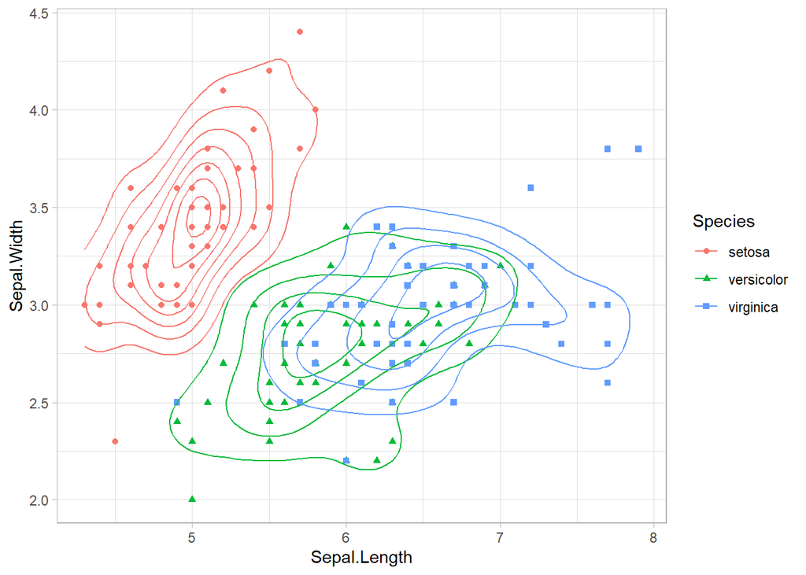

```r
library(ggplot2)
ggplot(data=iris,
             mapping=aes(x=Sepal.Length, y=Sepal.Width, color=Species, shape=Species)) +
  geom_point() +
  geom_density2d() +
  theme_light()
```

Again, we use the data set `iris` and on the x-axis is the variable `Petal.Length`. We distinguish the Species with a different color (`fill=`). We use the geom `geom_density()` for this plot. The scale functions allow us to name the axes and the function `coord_cartesian()` limits the x- and y-axis. Additionally, we use the theme `theme_bw()`, which creates a withe background.

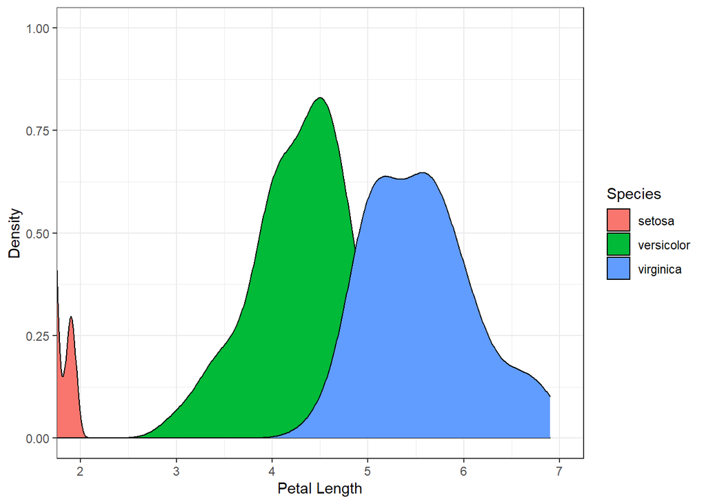

```r
ggplot(data=iris,
             mapping=aes(x=Petal.Length, fill = Species)) +
  geom_density() +
  scale_x_continuous(name = 'Petal Length') +
  scale_y_continuous(name = 'Density') +
  coord_cartesian(xlim=c(2,7), ylim=c(0,1)) +
  theme_bw()
```

We first have to compute the mean values of these four variables with the function `summarise()`. Then we have to reshape data with the function `pivot_longer()` and sort it with the function `arrange()`. Now we can use the function `ggplot()` to create the plot with the geom `geom_polygon()`. The set of aesthetic mapping we are using is `group=`, `color=`, `y=`, and `x=`. We use the a polar coordinate system for our pie chart `coord_polar()` and `theme_minimal()`. We let the names of the axes empty with `xlab()` and `ylab()`.

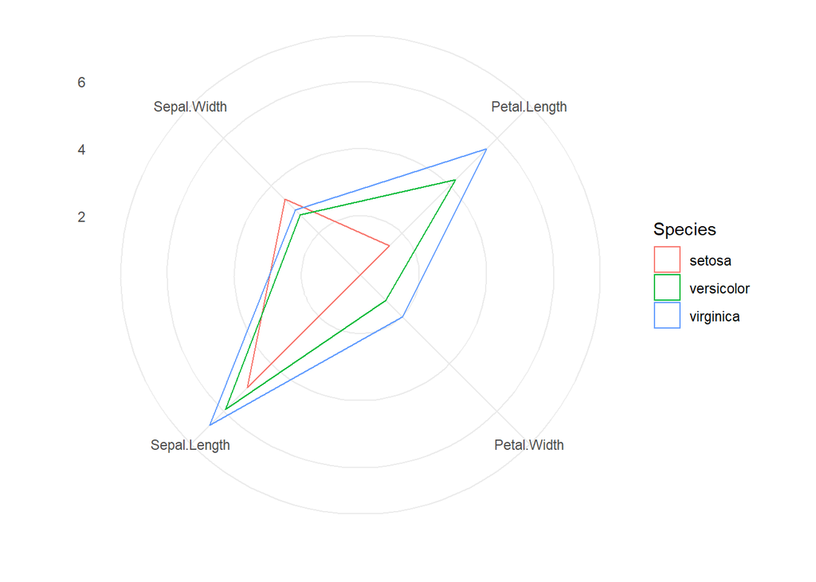

```r
library(tidyverse)
iris %>%
  group_by(Species) %>%
  summarise(Petal.Length = mean(Petal.Length),
                   Sepal.Length = mean(Sepal.Length),
                   Sepal.Width = mean(Sepal.Width),
                   Petal.Width = mean(Petal.Width)) %>%
  pivot_longer(cols = c("Petal.Length", "Sepal.Length","Sepal.Width","Petal.Width"),
               names_to = "variable", values_to = "value") %>%
  arrange(variable) %>%
  ggplot() +
  geom_polygon(mapping = aes(group = Species, color = Species, y = value, x = variable),
               fill = NA) +
  theme_minimal() +
  coord_polar()+
  xlab("")+
  ylab("")
```